# Stat4DS / Homework 03

Giuseppe Calabrese, Michele Cernigliaro

31/01/2019

## Exercise A.I: Ultra-fast exercise

*Look at the two DAGs and use d-separation + Markov condition to check whether the indicated conditional independence relationships are satisfied.*

For the exercise 1.A we can simply verify the conditional independences using *d-separation* method. We remark that, generally, two sets of nodes $\{X_A\}, \{X_B\}$ are d-separated by another set of nodes $\{X_C\}$ (the “observed” nodes) if, considering all the possible undirected paths from $\{X_A\}$ to $\{X_B\}$, we have that all the paths are **blocked**. d-separation implies conditional independece. To check wether a path is blocked or not, we have to see if at least one of the three condition is verified. The conditions can be consulted quickly on our [cheat_sheet](https://elearning.uniroma1.it/pluginfile.php/588226/mod_assign/intro/cheat_sheet_complete_v2.pdf).

#### 1) graph (1), check wheter the conditional independence $x_2 \perp x_3 \lvert \{x_1,x_6\}$ is satisfied.

First of all, we find out **two** undirected paths from $X_2$ to $X_3$:

1. The **first one** is the path **$X_2 - X_1 - X_3$**. We notice immediatly that it’s a common cause ($X_2 \leftarrow X_1 \rightarrow X_3$) where the observed value is $X_1$. Hence, we have a blocked path. We can move on analyzing the second path.
2. The **second one** is the path **$X_2 - X_6 - X_5 - X_3$**. The observed value in this case is $X_6$. Any condition doesn’t hold. So the path is not blocked. In detail, we have that $X_6$ is a collider ($X_2 \rightarrow X_6 \leftarrow X_5$), but $X_6$ is observed node. The 3rd condition is not verified. Moreover we have a chain ($X_3 \rightarrow X_5 \rightarrow X_6$) but $X_5$ is unobserved (we should have $X_6$ as “center” of the chain to satisfy the condition). Since we don’t have any condition satisfied, the second path is not blocked.

We don’t have all the paths blocked, hence we are not able to conclude that $X_2$ is d-separated from $X_3$ by $\{X_1,X_6\}$, thus the conditional independence relation is not satisfied.

#### 2.a) graph (2), check wheter the conditional independence $X_1 \perp X_6 \lvert \{X_2,X_3\}$ is satisfied.

Also in this case, we have **two** undirected paths, from $X_1$ to $X_6$:

1. $X_1 - X_2 - X_6$. We notice immediately that it’s a chain with observed value $X_2$ ($X_1 \rightarrow X_2 \rightarrow X_6$). Hence the path is blocked.
2. $X_1 - X_3 - X_5 - X_6$. We have another chain ($X_1 \rightarrow X_3 \rightarrow X_5$) with observed value $X_3$. Also this path is blocked.

Since every path is blocked, we can conclude that the conditional independence $X_1 \perp X_6 \lvert \{X_2,X_3\}$ is satisfied.

#### 2.b) For the conditional independence relation in (2), provide also a direct check by showing whether or not $p(x_6 \lvert x_{1:3}) = p(x_6 \lvert x_{2:3}$)

Starting with the definition of conditional probability, we have the following:

$$p(x_6 \lvert x_1,x_2,x_3) = \frac{p(x_1,x_2,x_3,x_6)}{p(x_1,x_2,x_3)}$$

We can rewrite the joint probabilities conditioning both numerator and denominator w.r.t. $x_2$ and $x_3$:

$$p(x_6 \lvert x_1,x_2,x_3) = \frac{p(x_1,x_6 \lvert x_2,x_3) \cdot p(x_2, x_3)}{p(x_1\lvert x_2,x_3) \cdot p(x_2, x_3)} = \frac{p(x_1,x_6 \lvert x_2,x_3) }{p(x_1\lvert x_2,x_3)}$$

Now, using the fact that $x_1 \perp x_6 \lvert x_2, x_3$ (as we demonstrated in the point 2.a), we factorize the numerator and we get that:

$$p(x_6 \lvert x_1,x_2,x_3) = \frac{p(x_1 \lvert x_2,x_3) \cdot p(x_6 \lvert x_2,x_3)}{p(x_1\lvert x_2,x_3)} = p(x_6 \lvert x_2,x_3)$$

As extra, we provide a demonstration of the probability without using the conditional independence of $x_1$ and $x_6$.

Using the Markov condition we can express the joint probability of our network as follows:

$$p(x_1, x_2, x_3, x_4, x_5, x_6) = p(x_1) p(x_2 \lvert x_1) p(x_3 \lvert x_1) p(x_4 \lvert x_2) p(x_5 \lvert x_3) p(x_6 \lvert x_2, x_5)$$

Now, starting with the LHS of the equation $p(x_6 \lvert x_{1:3})$, by the definition of conditional probability we have:

$$p(x_6 \lvert x_1,x_2,x_3) = \frac{p(x_1,x_2,x_3,x_6)}{p(x_1,x_2,x_3)} = \frac{p(x_1) p(x_2 \lvert x_1) p(x_3 \lvert x_1) p(x_6 \lvert x_2, x_5)}{p(x_1) p(x_2 \lvert x_1) p(x_3 \lvert x_1)} = \frac{p(x_2 \lvert x_1) p(x_3 \lvert x_1) p(x_6 \lvert x_2, x_5)}{p(x_2 \lvert x_1) p(x_3 \lvert x_1)}$$

- We notice that the numerator is the marginalization, of the joint distribution discribed by the graph, w.r.t. $x_1, x_4, x_5$. In formula:
  $$p(x_2 \lvert x_1) p(x_3 \lvert x_1) p(x_6 \lvert x_2, x_5) = \sum_{x_1} p(x_1) p(x_2 \lvert x_1) p(x_3 \lvert x_1) \sum_{x_4} p(x_4\lvert x_2) \sum_{x_5} p(x_5 \lvert x_3) p(x_6 \lvert x_2, x_5) = p(x_2, x_3, x_6)$$
- At the same time, the denominator is the marginalization, of the joint distribution described by the graph, w.r.t. $x_1, x_4, x_5, x_6$. In formula:
  $$p(x_2 \lvert x_1) p(x_3 \lvert x_1) = \sum_{x_1} p(x_1) p(x_2 \lvert x_1) p(x_3 \lvert x_1) \sum_{x_4} p(x_4 \lvert x_2)\sum_{x_5} p(x_5 \lvert x_3) \sum_{x_6}p(x_6 \lvert x_2, x_5) = p(x_2, x_3)$$

Substituting in the main equation, we get:
$$p(x_6 \lvert x_1,x_2,x_3) = \frac{p(x_2,x_3,x_6)}{p(x_2,x_3)} = p(x_6 \lvert x_2, x_3)$$

We have obtained $p(x_6 \lvert x_{1:3}) = p(x_6 \lvert x_{2:3})$. Thus, by definition of conditional independence, $x_6 \perp x_1 \lvert x_2, x_3$.

## Exercise A.II : Sampling a DAG

*Given the Bayesian model in DAG format, conditionally on $\boldsymbol{\mu} = [\mu_1, \mu_2]$ and $\sigma^2$, we assume that:*

$X = [X_1, X_2]^T \sim N_2(\boldsymbol{\mu}, \sigma^2 \mathbb{I}_2)$

$Y = [Y_1, Y_2]^T \sim N_2(\boldsymbol{\mu}, \sigma^2 \mathbb{I}_2)$

Therefore, $\boldsymbol{X} \in \mathbb{R}^2$ and $\boldsymbol{Y} \in \mathbb{R}^2$ are two random vectors with bivariate Normal distribution.

#### 1. Use what we studied about conditional distributions of multivariate Normal vectors to write down in formula the joint distribution corresponding to this dag.

We start expressing the joint distribution of the DAG using the Markov condition:

$$f(\boldsymbol{\mu}, \sigma^2, X_1,X_2,Y_1,Y_2 ) = f(\boldsymbol{\mu})f(\sigma^2)f(X_1 \lvert \mu_1,\sigma^2)f(X_2 \lvert X_1, \mu_2,\sigma^2) f(Y_1 \lvert \mu_1,\sigma^2) f(Y_2 \lvert Y_1, \mu_2, \sigma^2)$$

First of all, we assume that the components of $\boldsymbol\mu$ are independent. By the assumptions made on $\boldsymbol{X}$ and $\boldsymbol{Y}$, we notice that for both the random vectors $\boldsymbol{X}$ and $\boldsymbol{Y}$, we have a diagonal matrix $\Sigma$:

$$\Sigma =
\begin{bmatrix}
\sigma^2 & 0 \\
0 & \sigma^2 \\
\end{bmatrix}$$

There is no correlation between $X_1$ and $X_2$. Given that they’re jointly normally distributed, they are independent too. The precision matrix is:

$$\Sigma^{-1} =
\begin{bmatrix}
\frac{1}{\sigma^2} & 0 \\
0 & \frac{1}{\sigma^2} \\
\end{bmatrix}$$

We can conclude that $X_1$ and $X_2$ conditionally independent given $\boldsymbol{\mu}$ and $\sigma^2$. We have a similar situation with $Y_1$ and $Y_2$. So, in the end we have the following CI’s:

$X_1 \perp X_2 \mid \boldsymbol{\mu}, \sigma^2 \implies f(X_2 \mid X_1, \mu_2, \sigma^2) = f(X_2 \mid \mu_2, \sigma^2),$

$Y_1 \perp Y_2 \mid \boldsymbol{\mu}, \sigma^2 \implies f(Y_2 \mid Y_1, \mu_2, \sigma^2) = f(Y_2 \mid \mu_2, \sigma^2)$

Now, we can rewrite our joint distribution as follows:

$$f(\boldsymbol{\mu}, \sigma^2, X_1,X_2,Y_1,Y_2 ) = f(\mu_1)f(\mu_2)f(\sigma^2)f(X_1 \lvert \mu_1,\sigma^2)f(X_2 \lvert \mu_2,\sigma^2) f(Y_1 \lvert \mu_1,\sigma^2) f(Y_2 \lvert \mu_2, \sigma^2)$$

#### 2. Choose two suitable (prior) distributions for $\mu$ and $\sigma^2$ and write the corresponding R code to simulate a sample of $n$ = 10000 random vectors from the joint distribution by forward/ancestral sampling.

Since we have no clue of what the distribution represents, we choose two non-informative / flat priors. For $\mu_1$ and $\mu_2$ we choose two normal distributions, with mean 0 and standard deviation 1000. Instead for sigma, which is a positive scalar value for the variance of each random variable, we need a distribution that has positive support. We pick a gamma with shape 0.001 and rate 0.001.

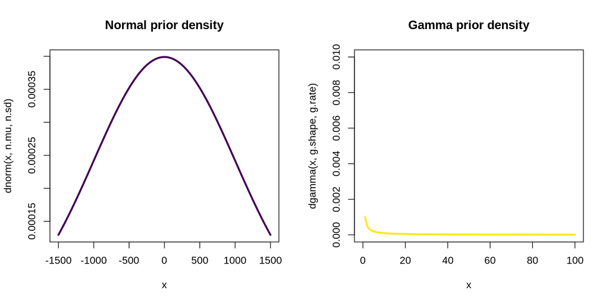

```r
n <- 10000 # sample size

# initializing the matrix with the sampled values
cnames <- c('mu1', 'mu2', 'sigma2', 'x1', 'x2', 'y1', 'y2')
data <- matrix(data = NA, nrow=n, ncol=length(cnames))
colnames(data) <- cnames

# defining our hyperparameters
n.mu <- 0         # mu for N
n.sd <- 1000      # mu for N
g.shape <- .001   # shape for Gamma
g.rate <-  .001   # rate for Gamma

# plotting the priors distributions
col = viridis::viridis(2)
par(mfrow = c(1,2))
# mu1 (the same as mu2)
curve(dnorm(x, n.mu, n.sd), xlim = c(-1500,1500), lwd = 3, col = col[1],
      main = "Normal prior density")

# sigma
curve(dgamma(x, g.shape, g.rate), xlim = c(0,100), ylim = c(0,.01),
      lwd = 3, col = col[2], main = "Gamma prior density")
```

Now that we’ve chosen our priors and we’ve set their hyperparameters, we simulate the sampling from the joint distribution using the ancestral/forward sampling:

```r
# forward sampling
for(i in 1:n){
  data[i, "mu1"] <- rnorm(1, n.mu, n.sd)           # sampling mu1
  data[i, "mu2"] <- rnorm(1, n.mu, n.sd)           # sampling mu2
  data[i, "sigma2"] <- rgamma(1, g.shape, g.rate)  # sampling sigma2

  data[i, "x1"] <- rnorm(1, data[i, "mu1"], sqrt(data[i, "sigma2"]))   # f(X1|mu1, sigma)
  data[i, "x2"] <- rnorm(1, data[i, "mu2"], sqrt(data[i, "sigma2"]))   # f(X2|mu2, sigma)
  data[i, "y1"] <- rnorm(1, data[i, "mu1"], sqrt(data[i, "sigma2"]))   # f(Y1|mu1, sigma)
  data[i, "y2"] <- rnorm(1, data[i, "mu2"], sqrt(data[i, "sigma2"]))   # f(Y2|mu2, sigma)
}
```

#### 3. Show a suitable plot with the empirical distribution of each component of the X vector. What theoretical distribution are you approximately describing?

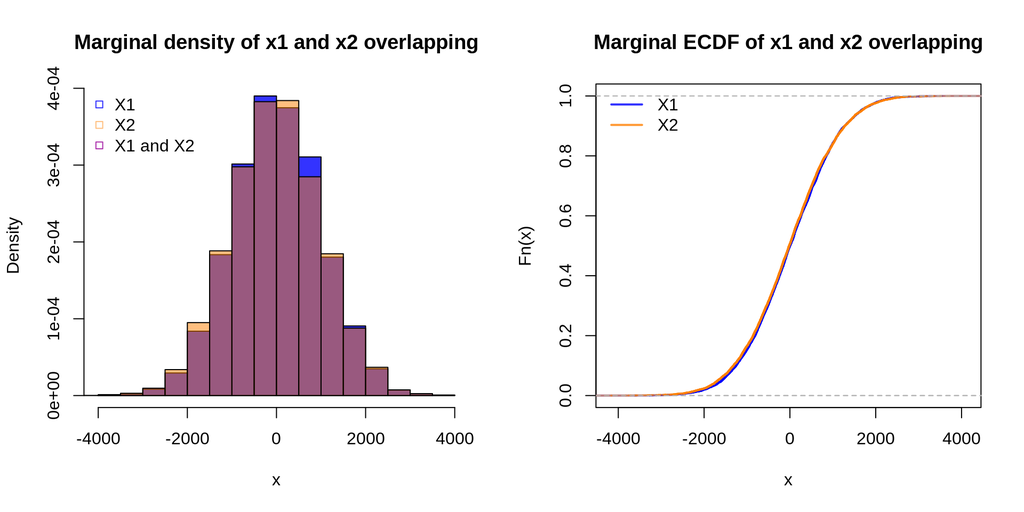

```r
par(mfrow = c(1,2))

# x1 and x2 histogram
hist(data[,"x1"], col = rgb(0,0,1,.8), probability = T,
     main = "Marginal density of x1 and x2 overlapping", xlab = "x")

hist(data[,"x2"], col = rgb(1,.5,0,.5), probability = T, add = T)
legend("topleft", legend = c("X1", "X2", "X1 and X2"), pch = 22, bty = "n",
       col = c(rgb(0,0,1,.8), rgb(1,.5,0,.5), rgb(.6,0,.6,.8)))

# x1 and x2 ecdf
plot(ecdf(data[,"x1"]), col = rgb(0,0,1,.5), lwd = 2,
     main = "Marginal ECDF of x1 and x2 overlapping")

plot(ecdf(data[,"x2"]), col = rgb(1,.5,0,.5), lwd = 2, add = T)
legend("topleft", legend = c("X1", "X2"), lwd = 2, bty = "n",
       col = c(rgb(0,0,1,.8), rgb(1,.5,0,.8)))
```

As we can see, first of all, it’s clear that both the components of $\boldsymbol{X}$ have a normal distribution. Moreover, since we have choosen for both $\mu_1$ and $\mu_2$ a Normal prior with the *same* hyperparameter $\mu_0 = 0$, they tend to have the same distribution.